# Crime In Baltimore

2017-12-26

# 1 - Team Members

- Oytun Deniz
- Selen Korkut Ozer
- Samet Boyaci
- Yigitcan Tunay

# 2 - Introduction

Violent crime in the United States has fallen over the last two decades. Even though the violent crime rate has been decreasing since 1990, the United States top the ranking of countries with the most prisoners. And Baltimore, Maryland is infamous for its very high crime rates. According to Forbes, Baltimore is the seventh dangerous city in the cities of United States. The violent crime rate is 1417 per 100.000 residents in a population of 626.848 people in 2017 so Baltimore is the one of the cities which is carrying high risk for local people. That is why, we thought that it would be interesting to analyze crimes in Baltimore.

# 3 - Project Details

# 4 - Preparation

## 4.1 - Loading Data

```r
setwd('~/gitProjects/DAE/')
bcd <- read.csv('Baltimore_Crime_Data.csv')
str(bcd)
```

```
## 'data.frame':    276529 obs. of  15 variables:
##  $ CrimeDate      : Factor w/ 2072 levels "01/01/2012","01/01/2013",..: 1472 1472 1472 1472 1472 1472 1472 1472 1472 1472 ...
##  $ CrimeTime      : Factor w/ 3017 levels "00:00:00","00:01:00",..: 2950 2880 2865 2857 2812 2748 2642 2691 2610 2610 ...
##  $ CrimeCode      : Factor w/ 81 levels "1F","1K","1O",..: 27 62 81 41 43 45 1 12 41 43 ...
##  $ Location       : Factor w/ 26009 levels "","& E BIDDLE ST",..: 15896 22874 20665 5391 967 24218 12556 15165 7697 2698 ...
##  $ Description    : Factor w/ 15 levels "AGG. ASSAULT",..: 13 4 15 1 6 5 7 14 1 6 ...
##  $ Inside.Outside : Factor w/ 5 levels "","I","Inside",..: 2 4 5 2 4 2 5 4 4 2 ...
##  $ Weapon         : Factor w/ 5 levels "","FIREARM","HANDS",..: 4 1 2 5 3 1 2 1 5 3 ...
##  $ Post           : int  913 133 524 934 113 922 232 123 641 332 ...
##  $ District       : Factor w/ 10 levels "","CENTRAL","EASTERN",..: 8 2 5 8 2 8 7 2 6 3 ...
##  $ Neighborhood   : Factor w/ 279 levels "","Abell","Allendale",..: 28 216 270 39 65 47 33 251 269 17 ...
##  $ Longitude      : num  -76.6 -76.6 -76.6 -76.6 -76.6 ...
##  $ Latitude       : num  39.2 39.3 39.3 39.3 39.3 ...
##  $ Location.1     : Factor w/ 95498 levels "","(39.2004100000, -76.5560200000)",..: 930 53781 81981 15697 22055 3586 14103 42341 53910 45269 ...
##  $ Premise        : Factor w/ 124 levels "","Alley","ALLEY",..: 97 108 107 97 108 97 107 108 108 97 ...
##  $ Total.Incidents: int  1 1 1 1 1 1 1 1 1 1 ...
```

## 4.2 - Loading Libraries

```r
library("data.table")
library("ggplot2")
library("dplyr")
library("ggplot2")
library("ggmap")
library("maps")
library("mapdata")
library("sqldf")
```

## 4.3 - Reformating features

### 4.3.1 - Dates

```r
bcd$CrimeDate<-as.Date(bcd$CrimeDate,format="%m/%d/%Y")
bcd$CrimeTimehour<- as.integer(substr(bcd$CrimeTime,0,2))
bcd$Year <- as.numeric (format(bcd$CrimeDate,"%Y"))
bcd$Month=as.numeric (format(bcd$CrimeDate,"%m"))
bcd$Day=as.numeric (format(bcd$CrimeDate,"%d"))
```

### 4.3.2 - Inside.OutSide

- The blank outside.inside rows are set as NA
- Inside.Outside column has 4 unique rows. O, I, Outside, Inside. We standardized these rows as O -> Outside, I -> Inside

```r
bcd$Inside.Outside[bcd$Inside.Outside=="O"] <- "Outside"
bcd$Inside.Outside[bcd$Inside.Outside=="I"] <- "Inside"
bcd$Inside.Outside[bcd$Inside.Outside==""] <- NA
```

### 4.3.3 - Location

- The blank location rows are set as NA

```r
bcd$Location[bcd$Location==""] <- NA
```

### 4.3.4 - District

- The blank district rows are set as NA

```r
bcd$District[bcd$District == ""] <- NA

#District Feature Reordered
bcd$District <- factor(bcd$District,levels = c("CENTER", "WESTERN", "NORTHWESTERN", "NORTHERN", "NORTHEASTERN", "EASTERN","SOUTHEASTERN","SOUTHERN","SOUTHWESTERN"))
```

## 4.4 - New Features

- Crime Group
- Crime Score
- Crime TimeLine

### 4.4.1 - Crime Group

```r
bcd$CrimeGroup[like(bcd$Description,"ROBBERY")] <- "ROBBERY"
bcd$CrimeGroup[like(bcd$Description,"ASSAULT")] <- "ASSAULT"
bcd$CrimeGroup[like(bcd$Description,"LARCENY")] <- "LARCENY"
bcd$CrimeGroup[like(bcd$Description,"ARSON")] <- "ARSON"
bcd$CrimeGroup[like(bcd$Description,"RAPE")] <- "RAPE"
bcd$CrimeGroup[like(bcd$Description,"SHOOTING")] <- "SHOOTING"
bcd$CrimeGroup[like(bcd$Description,"AUTO THEFT")] <- "AUTO THEFT"
bcd$CrimeGroup[like(bcd$Description,"HOMICIDE")] <- "HOMICIDE"
bcd$CrimeGroup[like(bcd$Description,"BURGLARY")] <- "BURGLARY"
```

### 4.4.2 - Crime Score

Crime score range is 1 to 10

```r
bcd$CrimeScore[like(bcd$Description,"ROBBERY - RESIDENCE")] <- 5
bcd$CrimeScore[like(bcd$Description,"AUTO THEFT")] <-4
bcd$CrimeScore[like(bcd$Description,"SHOOTING")] <-8
bcd$CrimeScore[like(bcd$Description,"AGG. ASSAULT")] <-6
bcd$CrimeScore[like(bcd$Description,"COMMON ASSAULT")] <-4
bcd$CrimeScore[like(bcd$Description,"BURGLARY")] <-10
bcd$CrimeScore[like(bcd$Description,"HOMICIDE")] <-10
bcd$CrimeScore[like(bcd$Description,"ROBBERY - STREET")] <-4
bcd$CrimeScore[like(bcd$Description,"ROBBERY - COMMERCIAL")] <-5
bcd$CrimeScore[like(bcd$Description,"LARCENY")] <-2
bcd$CrimeScore[like(bcd$Description,"LARCENY FROM AUTO")] <-1
bcd$CrimeScore[like(bcd$Description,"ARSON")] <-6
bcd$CrimeScore[like(bcd$Description,"ROBBERY - CARJACKING")] <-3
bcd$CrimeScore[like(bcd$Description,"ASSAULT BY THREAT")] <-1
bcd$CrimeScore[like(bcd$Description,"RAPE")] <-7

bcd$CrimeScore <- as.factor(bcd$CrimeScore)
```

### 4.4.3 Crime Time Line

We created 4 level from Crime Time Hour feature

00:00 - 06:00, 06:00 - 12:00, 12:00 - 18:00, 18:00 - 24:00

```r
bcd$CrimeTimeLine <- cut(bcd$CrimeTimehour, breaks=c(0,6,12,18,24), right=TRUE)
```

## 4.5 Data Virsulation

### 4.5.1 District

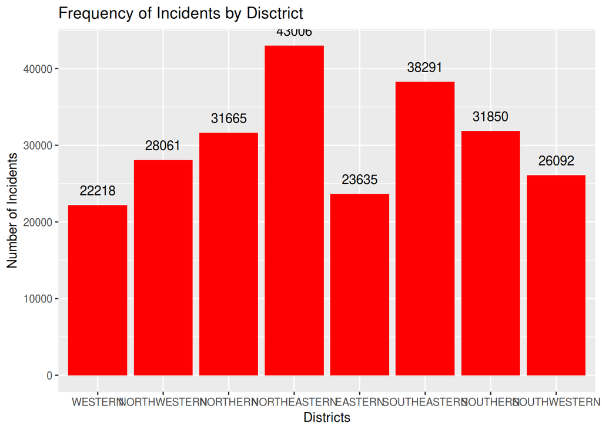

```r
ggplot(subset(bcd,!is.na(District)))+
  aes(x=District)+
  geom_bar(stat = "count",fill='red') +
  geom_text(stat="count",aes(label=..count..),vjust=-1)+
  labs(title="Frequency of Incidents by Disctrict",x="Districts",y="Number of Incidents")
```

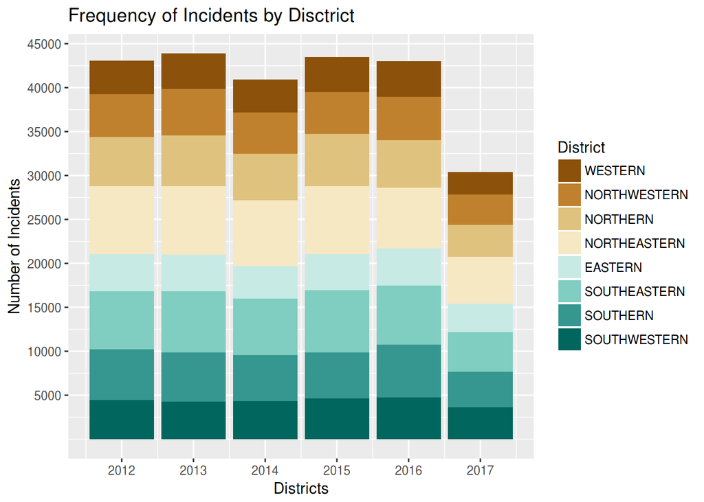

```r
ggplot(subset(bcd,!is.na(District)))+
  aes(x=Year, fill=District)+
  geom_bar(stat="count")+
  scale_x_continuous(breaks = seq(2012,2017,1))+
  scale_y_continuous(breaks = seq(5000,50000,5000))+
  scale_fill_brewer(type = 'div')+
  labs(title="Frequency of Incidents by Disctrict",x="Districts",y="Number of Incidents")
```

### 4.5.2 Neighborhood

```r
bcd.arrange.Neighborhood <- bcd %>%
    group_by(Neighborhood,Year) %>%
    summarise(count=n()) %>%
  arrange(desc(count))
```

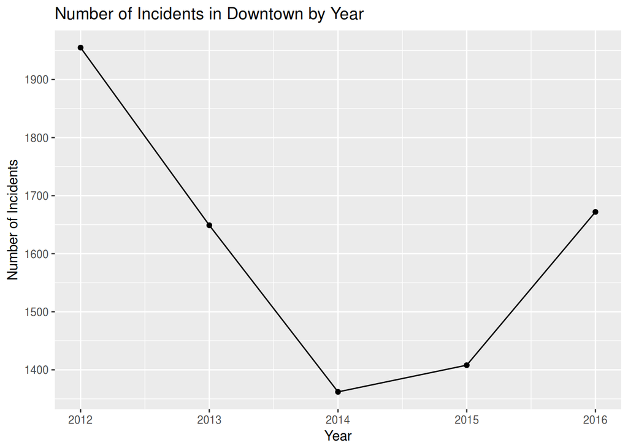

```r
#Especillay Downtown has highest number of Incidents
ggplot(subset(bcd.arrange.Neighborhood,Neighborhood=="Downtown" & Year!=2017))+
  aes(x=Year,y=count)+
  geom_line()  +
  geom_point()+
  scale_y_continuous(breaks = seq(1400,2000,100))+
  scale_fill_brewer(type = 'div')+
  labs(title="Number of Incidents in Downtown by Year",x="Year",y="Number of Incidents")
```

## 4.6 Data Visualization on Map

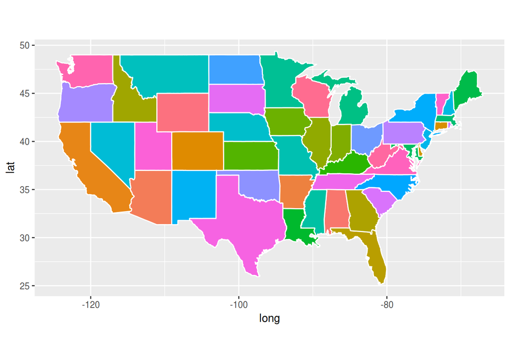

```r
states <- map_data("state")


ggplot(data = states) +
  geom_polygon(aes(x = long, y = lat, fill = region, group = group), color = "white") +
  coord_fixed(1.3) +
  guides(fill=FALSE)
```

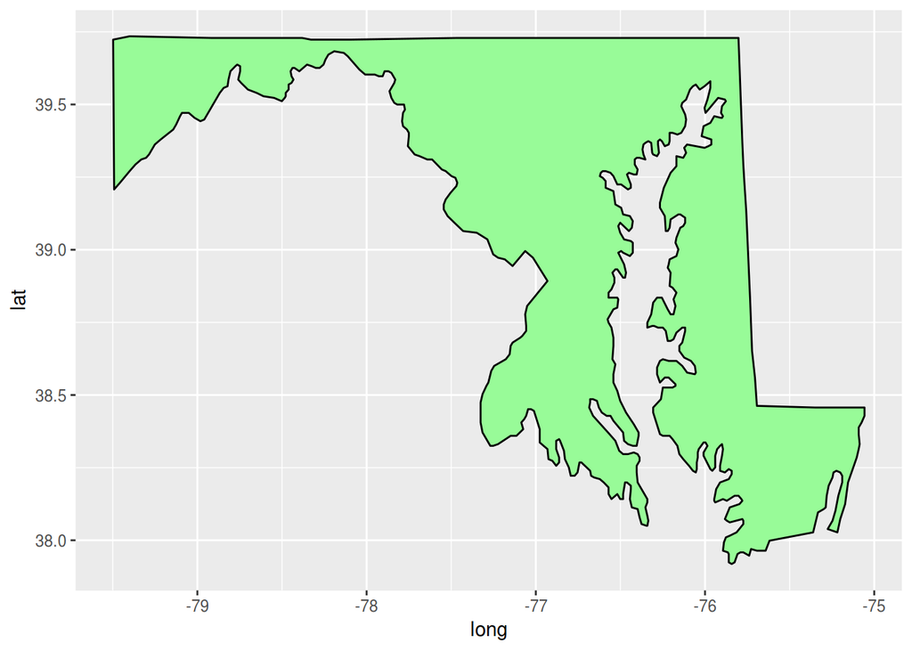

```r
maryland <- subset(states, region == c("maryland"))

ggplot(data = maryland) +
  geom_polygon(aes(x = long, y = lat), fill = "palegreen", color = "black")
```

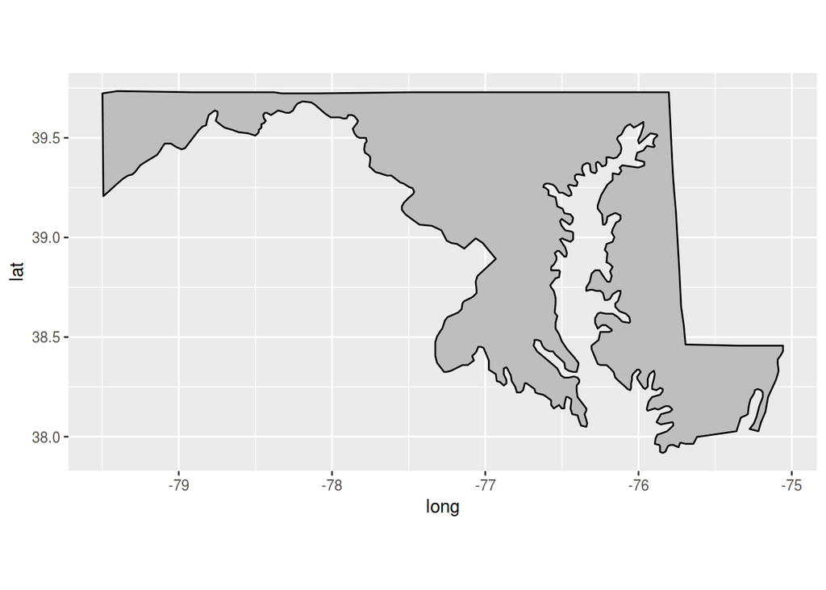

```r
maryland2 <- ggplot(data = maryland, mapping = aes(x = long, y = lat, group = group)) + coord_fixed(1.3) +
  geom_polygon(color = "black", fill = "gray")

maryland2
```

```r
sqldf("select min(Longitude),max(Longitude) from bcd")
```

| min(Longitude) | max(Longitude) |
| --- | --- |
| -76.71162 | -76.5285 |

```r
sqldf("select min(Latitude),max(Latitude) from bcd")
```

| min(Latitude) | max(Latitude) |
| --- | --- |
| 39.20041 | 39.37293 |

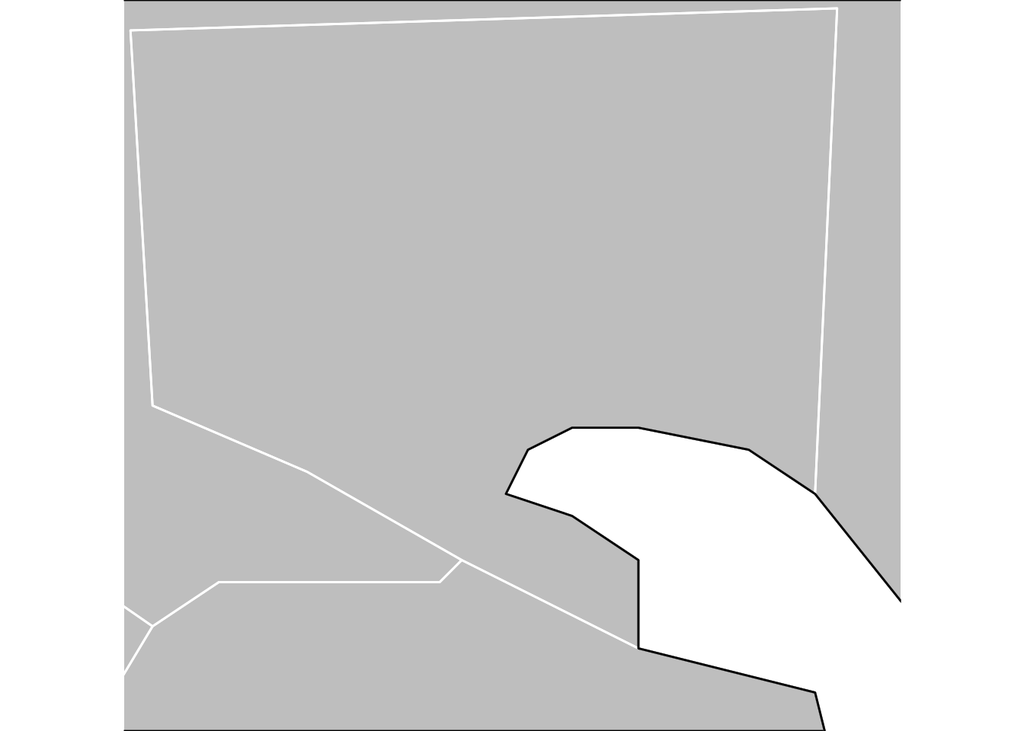

```r
counties <- map_data("county")

ca_county <- subset(counties, region == "maryland")

maryland3<- maryland2 + theme_nothing() +
  geom_polygon(data = ca_county, fill = NA, color = "white") +
  geom_polygon(color = "black", fill = NA)


# baltimore map

baltimore_map <- maryland3 +
  coord_fixed(xlim = c(-76.71162, -76.5285),  ylim = c(39.20041, 39.37293) )

baltimore_map
```

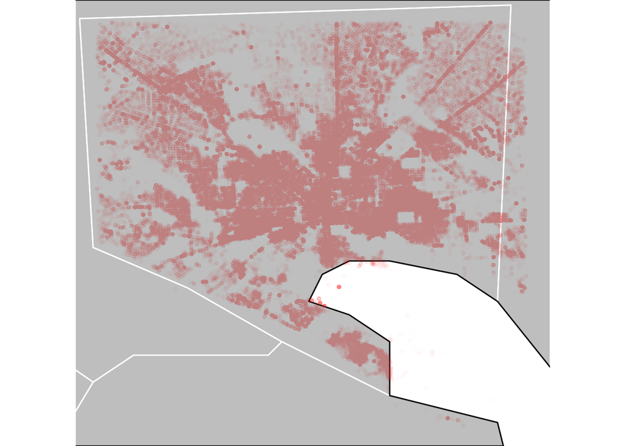

```r
baltimore_map +
  geom_point(data=bcd,aes(x = Longitude, y = Latitude,group=Total.Incidents),colour = 'Red',
             fill="Red",pch=21, size=1, alpha=I(0.005))
```

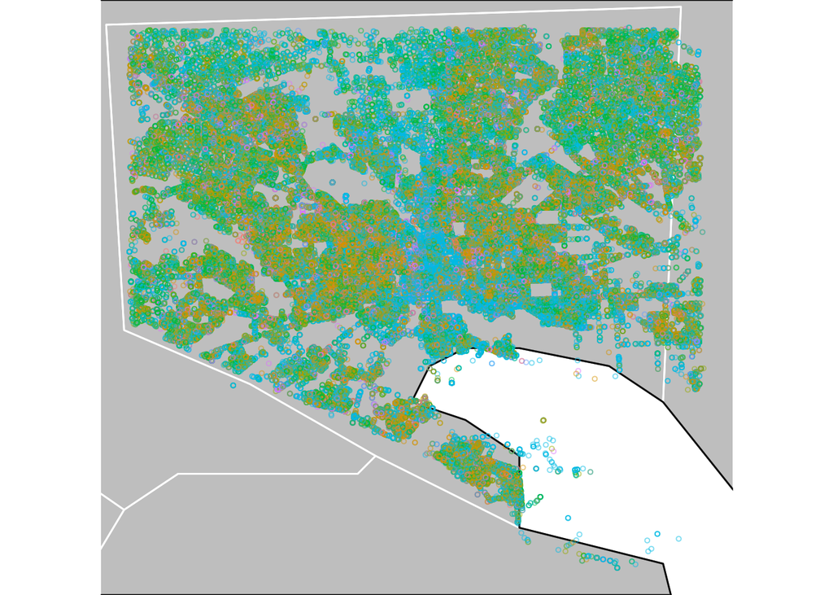

```r
baltimore_map +
  geom_point(data=bcd,aes(x = Longitude, y = Latitude,group=Total.Incidents,
                          colour=CrimeGroup),pch=21, size=1, alpha=I(0.5))
```